# Multivariate Statistics with R

Principal Components Analysis

Aja Murray, Aja.Murray@ed.ac.uk

# Overview

- Week 1: Dimension Reduction (PCA and EFA)
- Week 2: SEM I - Confirmatory Factor Analysis
- Week 3: SEM II - Path Analysis
- Week 4: SEM III - Full SEM
- Week 5: SEM IV - Practical Issues in SEM

# This Week

- Techniques
  - Principal Components Analysis (PCA)
  - Exploratory Factor Analysis (EFA)
- Key Functions
  - vss( )
  - fa.parallel( )
  - principal( )
  - fa( )
- Reading: *Principal Components Analysis* and *Exploratory Factor Analysis* Chapters (on *Learn* under ‘Reading’)

# Learning Outcomes

- Understand the principles of dimension reduction
- Understand thd difference between PCA and EFA
- Know how to perform and interpret PCA and EFA in R

# Dimension Reduction

- Summarise a set of variables in terms of a smaller number of dimensions
  - e.g., can 10 aggression items summarised in terms of ‘physical’ and ‘verbal’ aggression dimensions?
  1. I hit someone
  2. I kicked someone
  3. I shoved someone
  4. I battered someone
  5. I physically hurt someone on purpose
  6. I deliberately insulted someone
  7. I swore at someone
  8. I threatened to hurt someone
  9. I called someone a nasty name to their face
  10. I shouted mean things at someone

# Uses of dimension reduction techniques

[figure not shown]

- Theory testing
  - What are the number and nature of dimensions that best describe a theoretical construct?
- Test construction
  - How should I group my items into subscales?
  - Which items are the best measures of my constructs?
- Pragmatic
  - I have multicollinearity issues/too many variables, how can I defensibly combine my variables?

# Our running example

- A researcher has collected n=1000 responses to our 10 aggression items
- We’ll use this data to illustrate dimension reduction techniques

```r
library(psych)
describe(agg.items)
```

```
##        vars    n  mean   sd median trimmed  mad   min  max range  skew kurtosis
## item1     1 1000  0.05 1.01   0.02    0.03 1.00 -2.77 3.33  6.11  0.16    -0.10
## item2     2 1000  0.03 1.00   0.05    0.04 1.00 -3.07 3.65  6.71 -0.04     0.09
## item3     3 1000  0.01 1.02   0.01    0.00 1.03 -3.25 3.22  6.47  0.06    -0.02
## item4     4 1000 -0.01 1.00  -0.06   -0.03 0.99 -2.84 2.73  5.57  0.15    -0.16
## item5     5 1000  0.03 1.00   0.05    0.04 0.95 -3.48 3.39  6.86 -0.04     0.09
## item6     6 1000 -0.01 1.00   0.02    0.00 1.00 -2.95 2.87  5.82 -0.09    -0.19
## item7     7 1000  0.00 0.98   0.01    0.00 0.96 -3.14 3.31  6.44 -0.01     0.16
## item8     8 1000  0.00 1.01   0.01    0.01 0.99 -3.60 3.02  6.62 -0.08    -0.06
## item9     9 1000  0.02 0.96   0.01    0.01 0.95 -3.16 3.39  6.55  0.03     0.24
## item10   10 1000 -0.03 0.99  -0.02   -0.04 1.04 -2.81 2.83  5.64  0.02    -0.28
##          se
## item1  0.03
## item2  0.03
## item3  0.03
## item4  0.03
## item5  0.03
## item6  0.03
## item7  0.03
## item8  0.03
## item9  0.03
## item10 0.03
```

# PCA

- Starts with a correlation matrix

```r
#compute the correlation matrix for the aggression items
round(cor(agg.items),2)
```

```
##        item1 item2 item3 item4 item5 item6 item7 item8 item9 item10
## item1   1.00  0.57  0.48  0.42  0.58  0.01  0.10  0.02  0.06   0.01
## item2   0.57  1.00  0.60  0.51  0.68  0.00  0.06 -0.02  0.02  -0.01
## item3   0.48  0.60  1.00  0.48  0.61  0.00  0.05 -0.03  0.04   0.02
## item4   0.42  0.51  0.48  1.00  0.52  0.00  0.07  0.00  0.06   0.01
## item5   0.58  0.68  0.61  0.52  1.00 -0.03  0.00 -0.07 -0.03  -0.05
## item6   0.01  0.00  0.00  0.00 -0.03  1.00  0.57  0.61  0.43   0.46
## item7   0.10  0.06  0.05  0.07  0.00  0.57  1.00  0.77  0.56   0.58
## item8   0.02 -0.02 -0.03  0.00 -0.07  0.61  0.77  1.00  0.57   0.64
## item9   0.06  0.02  0.04  0.06 -0.03  0.43  0.56  0.57  1.00   0.44
## item10  0.01 -0.01  0.02  0.01 -0.05  0.46  0.58  0.64  0.44   1.00
```

# What PCA does

[figure not shown]

- Repackages the variance from the correlation matrix into a set of **components**
- Components = orthogonal (i.e.,uncorrelated) linear combinations of the original variables
  - 1st component is the linear combination that accounts for the most possible variance
  - 2nd accounts for second-largest after the variance accounted for by the first is removed
  - 3rd…etc…
- Each component accounts for as much remaining variance as possible
- There are as many components are there were variables in original correlation matrix

# Eigendecomposition

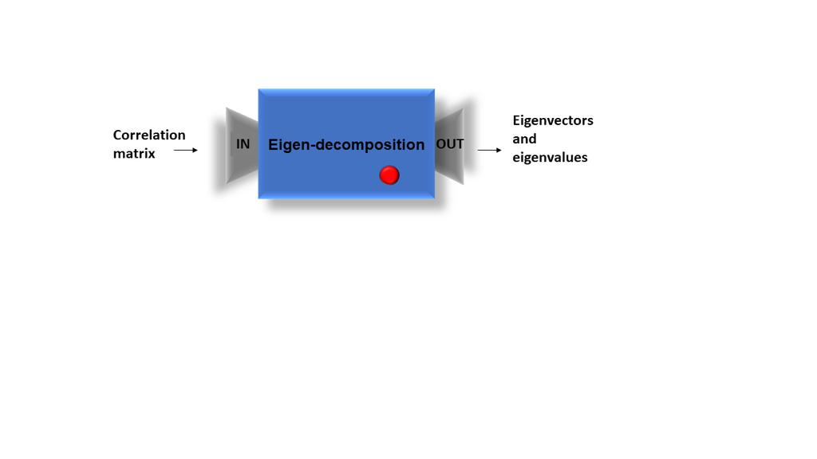

- Components are formed using an **eigen-decomposition** of the correlation matrix
- Eigen-decomposition is a transformation of the correlation matrix to re-express it in terms of **eigenvalues** and **eigenvectors**

# Eigenvalues and eigenvectors

```
## [1] "e1" "e2" "e3" "e4" "e5"
```

```
##       component1 component2 component3 component4 component5
## item1 "w11"      "w12"      "w13"      "w14"      "w15"
## item2 "w21"      "w22"      "w23"      "w24"      "w25"
## item3 "w31"      "w32"      "w33"      "w34"      "w35"
## item4 "w41"      "w42"      "w43"      "w44"      "w45"
## item5 "w51"      "w52"      "w53"      "w54"      "w55"
```

- There is one eigenvector and one eigenvalue for each component
- Eigenvalues are a measure of the size of the variance packaged into a component
  - Larger eigenvalues mean that the component accounts for a large proportion of the variance in the original correlation matrix
- Eigenvectors are sets of **weights** (one weight per variable in original correlation matrix)
  - e.g., if we had 5 variables each eigenvector would contain 5 weights
  - Larger weights mean a variable makes a bigger contribution to the component

# Eigen-decomposition of aggression item correlation matrix

- We can use the eigen() function to conduct an eigen-decomposition for our 10 aggression items

```r
eigen(cor(agg.items))
```

```
## eigen() decomposition
## $values
##  [1] 3.3013609 3.1698873 0.6029067 0.5743282 0.5429745 0.5116997 0.3905950
##  [8] 0.3765898 0.3167663 0.2128917
##
## $vectors
##            [,1]       [,2]         [,3]        [,4]         [,5]         [,6]
##  [1,] 0.2079285 -0.3713962  0.355601465  0.48498588  0.103294603 -0.498458741
##  [2,] 0.2051912 -0.4278001  0.144232702  0.01030331 -0.006785705  0.128624613
##  [3,] 0.1978449 -0.3996382  0.003597695 -0.16947491  0.037804737  0.646157265
##  [4,] 0.1906344 -0.3550759 -0.704089975 -0.36436700 -0.099700964 -0.428763818
##  [5,] 0.1790295 -0.4472352  0.156913474 -0.01864123 -0.029910263  0.067614549
##  [6,] 0.3690024  0.1922716  0.305764512 -0.28331331 -0.714670868 -0.009269219
##  [7,] 0.4478574  0.1795467  0.020319398  0.02789068  0.032803439 -0.135510244
##  [8,] 0.4367826  0.2412870  0.038528274 -0.04049953  0.059948382 -0.102800119
##  [9,] 0.3709736  0.1623312 -0.475391348  0.64089676 -0.091729713  0.314895318
## [10,] 0.3768120  0.1986626  0.104789671 -0.33078211  0.673187501  0.029822334
##             [,7]       [,8]         [,9]        [,10]
##  [1,] -0.3863452  0.1877529  0.112543933  0.029259588
##  [2,]  0.4987072 -0.3627814  0.597254092  0.018773108
##  [3,] -0.2682517  0.5259331  0.051049638  0.047884677
##  [4,] -0.1110514  0.0173993  0.050696197  0.009471192
##  [5,]  0.1623547 -0.3358242 -0.773362617 -0.016332848
##  [6,] -0.3090563 -0.1821124  0.085795203 -0.078921679
##  [7,]  0.4430340  0.4301328 -0.090975182 -0.597483933
##  [8,]  0.2678414  0.2016358 -0.088806237  0.783219466
##  [9,] -0.1512092 -0.2600589 -0.006918045 -0.034138523
## [10,] -0.3240060 -0.3420315  0.061512584 -0.135381634
```

# BREAK 1

- Time for a pause
- Quiz question:
  - What is the name of the process by which a correlation matrix is transformed into eigenvectors and eigenvalues?
    - 1. eigen-sedimentation
    - 2. eigen-consolidation
    - 3. eigen-diversification
    - 4. eigen-decomposition

# WELCOME BACK 1

- Welcome back!
- The answer to the quiz question is…
  - 1. eigen-sedimentation
  - 2. eigen-consolidation
  - 3. eigen-diversification
  - 4. **eigen-decomposition**

# How many components to keep?

[figure not shown]

- Eigen-decomposition repackages the variance but does not reduce our dimensions
- Dimension reduction comes from keeping only the largest components
- Assume the others can be dropped with little loss of information
- Our decisions on how many components to keep can be guided by several methods
  - Scree plot
  - Minimum average partial test (MAP)
  - Parallel analysis

# Other considerations in how many components to keep

[figure not shown]

- Substantive considerations
  - Do the selected components make theoretical sense?
- Practical considerations
  - Are some components too ‘minor’ to be reliable?

# Kaiser criterion

[figure not shown]

- Keeps number of components with eigenvalue >1
- DO NOT USE Kaiser criterion
- Often suggests keeping far too many components

# Scree plot

[figure not shown]

- Based on plotting the eigenvalues
- Looking for a sudden change of slope
- Assumed to potentially reflect point at which components become substantively unimportant

# Constructing a scree plot

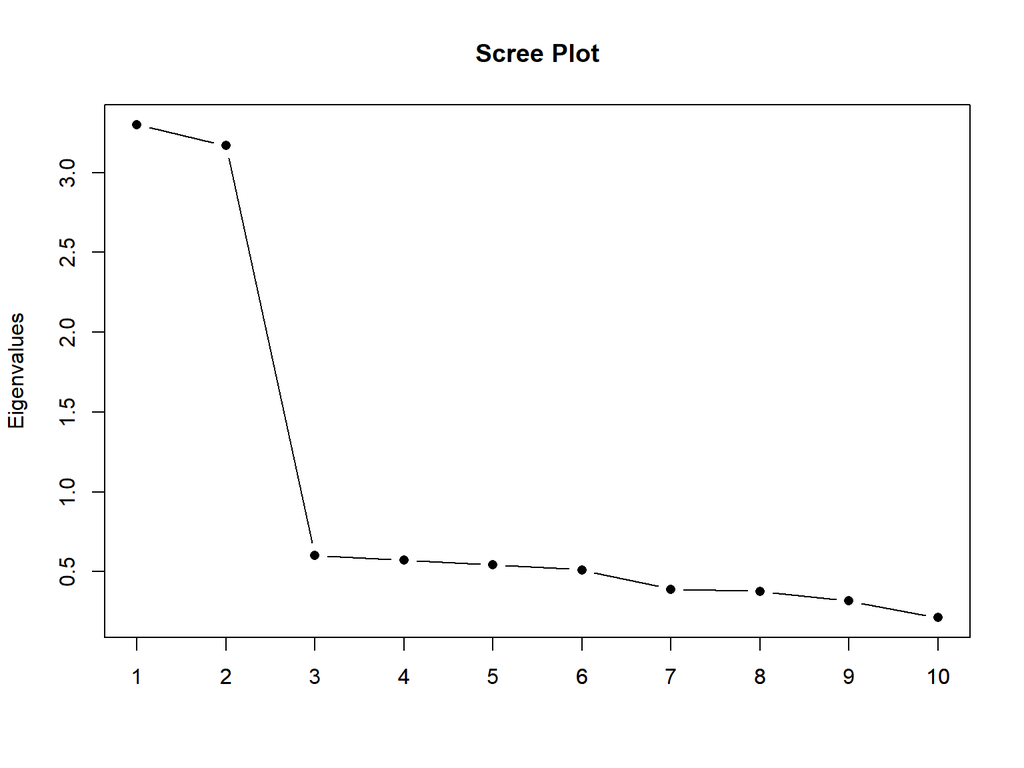

- Eigenvalue plot
  - x-axis is component number
  - y-axis is eigenvalue for each component
- Keep the components with eigenvalues above a kink in the plot

# Further scree plot examples

- Scree plots vary in how easy it is to interpret them

```
## [1] 10
```

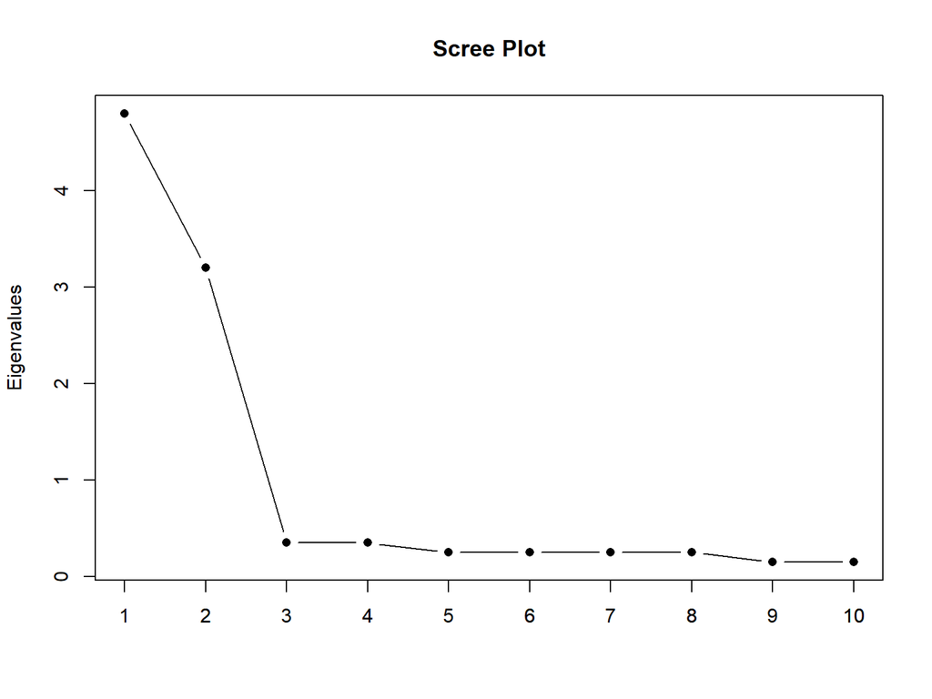

# Further scree plot examples

```
## [1] 10
```

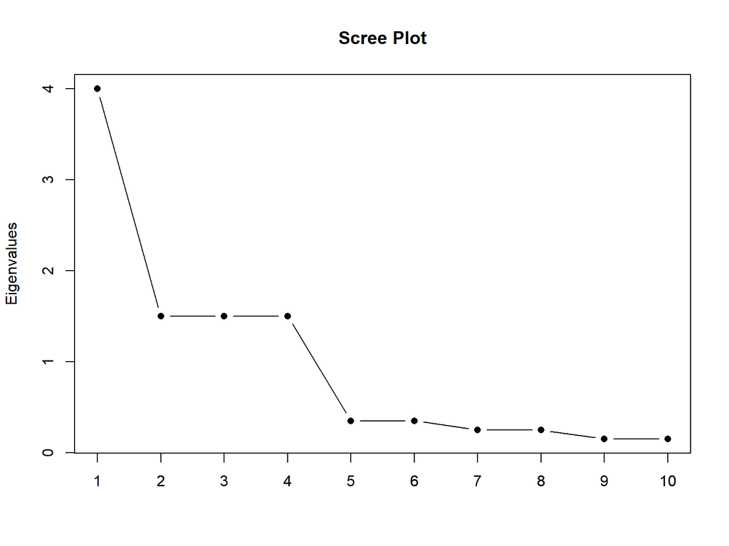

# Further scree plot examples

```
## [1] 10
```

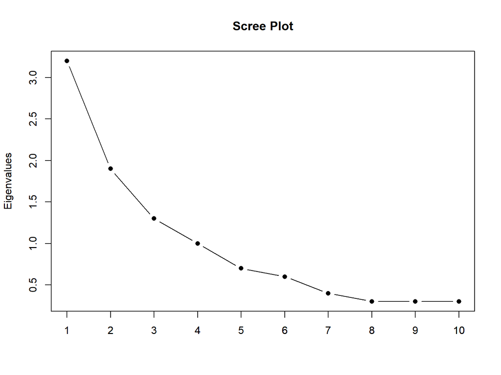

# Minimum average partial test (MAP)

[figure not shown]

- Extracts components iteratively from the correlation matrix
- Computes the average squared partial correlation after each extraction
- At first this quantity goes down with each component extracted but then it starts to increase again
- MAP keeps the components from point at which the average squared partial correlation is at its smallest

# MAP test for the aggression items

- We can obtain the results of the MAP test via the vss( ) function from the psych package

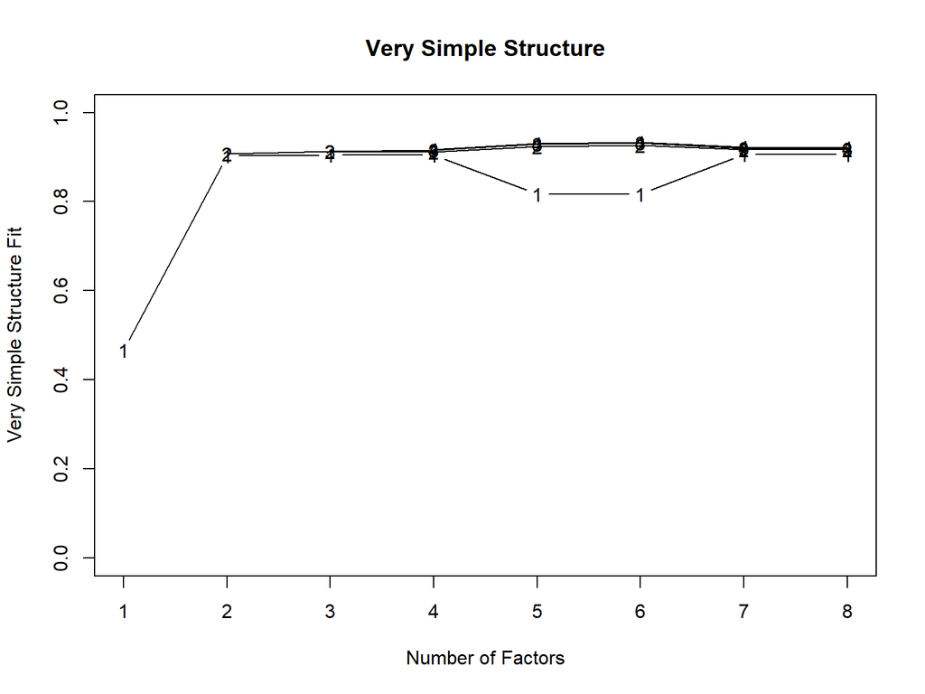

```
##
## Very Simple Structure
## Call: vss(x = agg.items)
## Although the VSS complexity 1 shows  8  factors, it is probably more reasonable to think about  4  factors
## VSS complexity 2 achieves a maximimum of 0.93  with  6  factors
##
## The Velicer MAP achieves a minimum of 0.03  with  2  factors
## BIC achieves a minimum of  NA  with  2  factors
## Sample Size adjusted BIC achieves a minimum of  NA  with  2  factors
##
## Statistics by number of factors
##   vss1 vss2   map dof   chisq prob sqresid  fit RMSEA  BIC SABIC complex
## 1 0.47 0.00 0.149  35 2.2e+03 0.00    12.1 0.47  0.25 1922  2033     1.0
## 2 0.90 0.91 0.029  26 2.4e+01 0.60     2.1 0.91  0.00 -156   -73     1.0
## 3 0.90 0.91 0.055  18 1.2e+01 0.83     2.0 0.91  0.00 -112   -55     1.1
## 4 0.90 0.91 0.101  11 4.7e+00 0.94     1.9 0.92  0.00  -71   -36     1.1
## 5 0.82 0.92 0.164   5 1.7e+00 0.89     1.6 0.93  0.00  -33   -17     1.2
## 6 0.82 0.93 0.253   0 3.8e-01   NA     1.5 0.93    NA   NA    NA     1.2
## 7 0.91 0.92 0.362  -4 3.8e-07   NA     1.7 0.92    NA   NA    NA     1.1
## 8 0.91 0.92 0.452  -7 6.1e-08   NA     1.7 0.92    NA   NA    NA     1.1
##    eChisq    SRMR  eCRMS eBIC
## 1 6.1e+03 2.6e-01 0.2943 5823
## 2 9.2e+00 1.0e-02 0.0133 -170
## 3 4.4e+00 7.0e-03 0.0111 -120
## 4 1.7e+00 4.4e-03 0.0089  -74
## 5 5.4e-01 2.5e-03 0.0074  -34
## 6 1.1e-01 1.1e-03     NA   NA
## 7 8.6e-08 9.8e-07     NA   NA
## 8 1.8e-08 4.4e-07     NA   NA
```

```r
library(psych)
vss(agg.items)
```

# The MAP values

- The averaged squared partial correlation values

```r
VSS$map
```

```
## [1] 0.14866850 0.02934848 0.05541998 0.10132725 0.16440338 0.25277746 0.36155404
## [8] 0.45241197
```

# Parallel analysis

[figure not shown]

- Simulates datasets with same number of participants and variables but no correlations
- Computes an eigen-decomposition for the simulated datasets
- Compares the average eigenvalue across the simulated datasets for each component
- If a real eigenvalue exceeds the corresponding average eigenvalue from the simulated datasets it is retained
- We can also use alternative methods to compare our real versus simulated eigenvalues
  - e.g. 95% percentile of the simulated eigenvalue distributions

# Parallel analysis for the aggression items

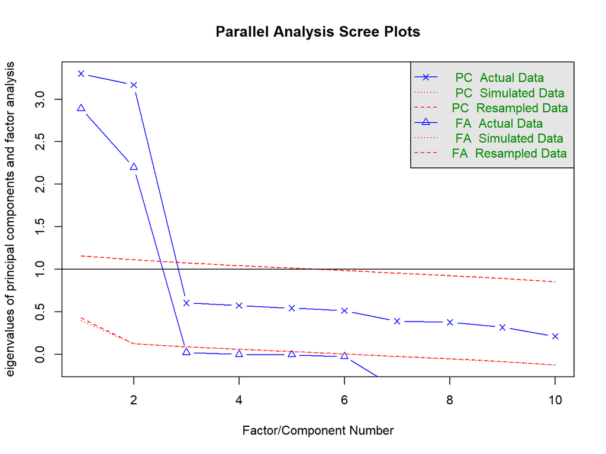

```
## Parallel analysis suggests that the number of factors =  2  and the number of components =  2
```

```r
fa.parallel(agg.items, n.iter=500)
```

# The fa.parallel( ) function

- Notice the function also gives us a scree plot
- We can use this to find a point of inflection
  - Use the ‘PC Actual Data’ datapoints
- However, if we want to include a scree plot in a report we should construct our own, e.g.:

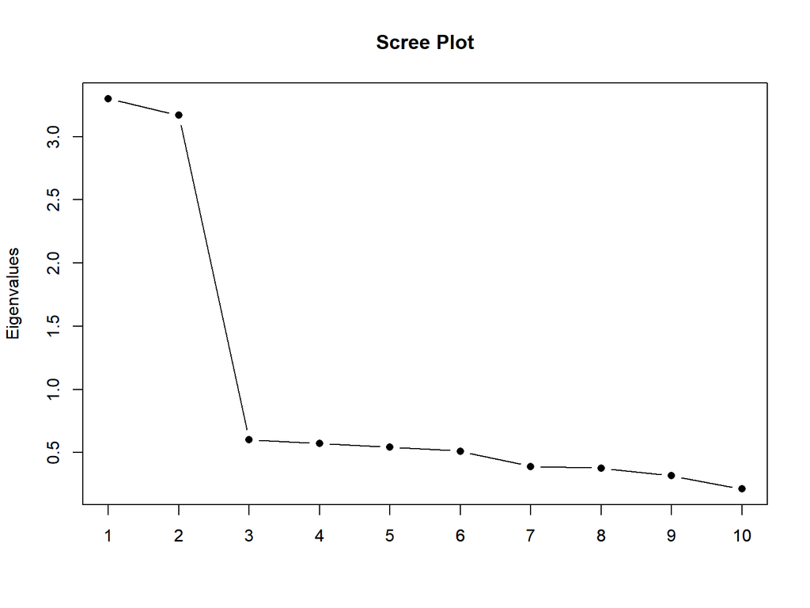

```r
eigenvalues<-eigen(cor(agg.items))$values
plot(eigenvalues, type = 'b', pch = 16,
     main = "Scree Plot", xlab="", ylab="Eigenvalues")
axis(1, at = 1:10, labels = 1:10)
```

# Limitations of scree, MAP, and parallel analysis

- There is no one right answer about the number of components to retain
- Scree plot, MAP and parallel analysis frequently disagree
- Each method has weaknesses
  - Scree plots are subjective and may have multiple or no obvious kinks
  - Parallel analysis sometimes suggest too many components
  - MAP sometimes suggests too few components
- Examining the PCA solutions should also form part of the decision

# BREAK 2

- Time for a pause
- Quiz question:
  - Which components are retained based on a scree plot?
    - 1. Those with eigenvalues up to and including the kink
    - 2. Those with eigenvalues >2
    - 3. Those with eigenvalues before the kink
    - 4. Those up to the point where the average squared partial correlation is at its minimum

# WELCOME BACK 2

- Welcome back!
- The answer to the quiz question is…
  - Which components are retained based on a scree plot?
    - 1. Those with eigenvalues up to and including the kink
    - 2. Those with eigenvalues >2
    - 3. **Those with eigenvalues before the kink**
    - 4. Those up to the point where the average squared partial correlation is at its minimum

# Running a PCA with a reduced number of components

- We can run a PCA keeping just a selected number of components
- We do this using the principal() function from then psych package
- We supply the dataframe or correlation matrix as the first argument
- We specify the number of components to retain with the nfactors= argument
- It can be useful to compare and constrast the solutions with different numbers of components
  - Allows us to check which solutions make most sense based on substantive/practical considerations

```r
PC2<-principal(agg.items, nfactors=2)
PC3<-principal(agg.items, nfactors=3)
```

# Interpreting the components

- Once we have decided how many components to keep (or to help us decide) we examine the PCA solution
- We do this based on the component loadings
  - Component loadings are calculated from the values in the eigenvectors
  - They can be interpreted as the correlations between variables and components

# The component loadings

- Component loading matrix
- RC1 and RC2 columns show the component loadings

```r
PC2<-principal(r=agg.items, nfactors=2)
PC2$loadings
```

```
##
## Loadings:
##        RC1    RC2
## item1          0.761
## item2          0.848
## item3          0.797
## item4          0.720
## item5          0.857
## item6   0.753
## item7   0.871
## item8   0.902
## item9   0.732
## item10  0.771
##
##                  RC1   RC2
## SS loadings    3.275 3.197
## Proportion Var 0.327 0.320
## Cumulative Var 0.327 0.647
```

# Interpreting the components

1. I hit someone
2. I kicked someone
3. I shoved someone
4. I battered someone
5. I physically hurt someone on purpose
6. I deliberately insulted someone
7. I swore at someone
8. I threatened to hurt someone
9. I called someone a nasty name to their face
10. I shouted mean things at someone

# Rotation of components

[figure not shown]

- Rotation takes an initial PCA solution and transforms it to make it more interpretable
- An initial PCA solution typically has:
  - has high loadings on the first component
  - has a mix of positive and negative loadings on subsequent components
  - is difficult to interpret
- We typically try to achieve *simple structure* with a rotation
  - each item has a high loading on one component and close to zero loading on all others

# Initial PCA solution for the aggression items

```r
PC_initial<-principal(r=agg.items, nfactors=2, rotate='none')
PC_initial$loadings
```

```
##
## Loadings:
##        PC1    PC2
## item1   0.378  0.661
## item2   0.373  0.762
## item3   0.359  0.712
## item4   0.346  0.632
## item5   0.325  0.796
## item6   0.670 -0.342
## item7   0.814 -0.320
## item8   0.794 -0.430
## item9   0.674 -0.289
## item10  0.685 -0.354
##
##                  PC1   PC2
## SS loadings    3.301 3.170
## Proportion Var 0.330 0.317
## Cumulative Var 0.330 0.647
```

# Different types of rotation

- The initial (unrotated) loading matrix is transformed by multiplication by a *transformation matrix*
- Different transformation matrices are used to achieve different transformations
- The most important distinction is between *orthogonal* versus *oblique* rotations
  - Orthogonal rotations force the components to remain uncorrelated
    - They include varimax, quartimax and equamax
  - Oblique rotations allow the components to be correlated
    - They include oblimin, promax, direct oblimin, and quartimin

# Choosing a rotation

- Orthogonal rotations are useful for e.g. reducing multicollinearity in regression
- Oblique rotations better reflect the reality that psychological constructs tend to be correlated
- Advice: use an oblique rotation and switch to orthogonal if correlation is very low
  - Oblimin is a good choice for oblique rotation
  - Varimax is a good choice for orthogonal rotation
  - … but trying a few and comparing is a good idea

# Interpreting an oblique rotation

- When an orthogonal rotation is used only one loading matrix is produced
- When an oblique rotation is used two loading matrices are produced:
  - *structure matrix* (correlations between the components and the variables)
  - *pattern matrix* (regression weights from the components to the variables)
- Pattern is likely to be most useful for interpreting the components

# PCA solution for the aggression items using an oblique rotation

```r
PC2<-principal(r=agg.items, nfactors=2, rotate='oblimin')
PC2$loadings
```

```
##
## Loadings:
##        TC1    TC2
## item1          0.760
## item2          0.848
## item3          0.797
## item4          0.720
## item5          0.859
## item6   0.753
## item7   0.871
## item8   0.902
## item9   0.732
## item10  0.770
##
##                  TC1   TC2
## SS loadings    3.276 3.195
## Proportion Var 0.328 0.319
## Cumulative Var 0.328 0.647
```

# PCA solution for the aggression items using an oblique rotation

```r
PC2<-principal(r=agg.items, nfactors=2, rotate='oblimin')
PC2$Phi
```

```
##          TC1      TC2
## TC1 1.000000 0.010516
## TC2 0.010516 1.000000
```

# BREAK 3

- Time for a pause
- Quiz question:
  - Under an oblique rotation which matrix contains the weights for the regression of the components on the original variables?
    - 1. pattern matrix
    - 2. structure matrix
    - 3. eigenvector matrix
    - 4. eigenvalue matrix

# WELCOME BACK 3

- Welcome back!
- The answer to the quiz question is..
  - Under an oblique rotation which matrix contains the weights for the regression of the components on the original variables?
  - 1. **pattern matrix**
  - 2. structure matrix
  - 3. eigenvector matrix
  - 4. eigenvalue matrix

# How good is my PCA solution?

- A good PCA solution explains the variance of the original correlation matrix in as few components as possible

```r
principal(r=agg.items, nfactors=2, rotate='oblimin')
```

```
## Principal Components Analysis
## Call: principal(r = agg.items, nfactors = 2, rotate = "oblimin")
## Standardized loadings (pattern matrix) based upon correlation matrix
##          TC1   TC2   h2   u2 com
## item1   0.05  0.76 0.58 0.42   1
## item2   0.00  0.85 0.72 0.28   1
## item3   0.01  0.80 0.64 0.36   1
## item4   0.03  0.72 0.52 0.48   1
## item5  -0.06  0.86 0.74 0.26   1
## item6   0.75 -0.02 0.57 0.43   1
## item7   0.87  0.06 0.76 0.24   1
## item8   0.90 -0.05 0.81 0.19   1
## item9   0.73  0.03 0.54 0.46   1
## item10  0.77 -0.02 0.59 0.41   1
##
##                        TC1  TC2
## SS loadings           3.28 3.19
## Proportion Var        0.33 0.32
## Cumulative Var        0.33 0.65
## Proportion Explained  0.51 0.49
## Cumulative Proportion 0.51 1.00
##
##  With component correlations of
##      TC1  TC2
## TC1 1.00 0.01
## TC2 0.01 1.00
##
## Mean item complexity =  1
## Test of the hypothesis that 2 components are sufficient.
##
## The root mean square of the residuals (RMSR) is  0.06
##  with the empirical chi square  347.2  with prob <  6.8e-58
##
## Fit based upon off diagonal values = 0.97
```

# Computing scores for the components

- After conducting a PCA you may want to create scores for the new dimensions
  - e.g., to use in a regression
- Simplest method is to sum the scores for all items with loadings >|.3|
- Better method is to compute them taking into account the weights

# Computing component scores in R

```r
PC<-principal(r=agg.items, nfactors=2, rotate='oblimin')
scores<-PC$scores
head(scores)
```

```
##             TC1        TC2
## [1,]  1.0761011 -1.3395389
## [2,]  3.1652231  0.7251142
## [3,] -1.6724205  2.5014868
## [4,] -2.9717475 -1.7508274
## [5,] -0.1027386  2.2845840
## [6,] -0.8727964 -1.6079809
```

# Reporting a PCA

- Main principles: transparency and reproducibility
- Method
  - Methods used to decide on number of factors
  - Rotation method
- Results
  - Results of MAP, parallel analysis, scree test (& any other considerations in choice of number of components)
  - How many components were retained
  - The loading matrix for the chosen solution (pattern for oblique rotations)
  - Correlations between components (for oblique rotations)
  - Variance expained by components
  - Labelling and interpretation of the components

# PCA Summary

- PCA is a common dimension reduction technique
- Steps are:
  - Decide how many components to keep (scree plot, parallel analysis, MAP test)
  - Rotate (orthogonal versus oblique)
  - Interpret solution (loadings, component correlations, variance explained)
- There are many subjective decision points - critical thinking is needed
- Number of components is arguably most important decision

# END OF PCA

[figure not shown]

- End of PCA section!
- Next we will cover **exploratory factor analysis**